# Lab03

Kunxi Li

11/11/2023

## Spatial Temporal analysis in R

R’s versatility and extensive ecosystem of packages make it a powerful tool for studying the dynamic interplay of space and time in data.

### Data to download

Download the project folder from canvas for this lab. We will be using the packages `ggplot()` and `gganimate()` to explore spatial dimensions `gganimate` is an extension of the grammar of graphics, as implemented by the ggplot2 package, that adds support for declaring animations using an API familiar to users of ggplot2.

```r
library(readr)
library(ggplot2)
library(ggthemes)
library(gganimate)
library(foreign)
library(dplyr)
library(rnaturalearth)
library(rnaturalearthdata)
library(gifski)
library(lubridate)
#library(tidyverse)
library(wesanderson)
```

1. Let’s open the data

```r
MichFlickr <- read.csv("MichiganFlickr.csv")
```

2. First let’s look at distribution of the data. To plot time series data, we need to change the formate so R understand that it should be read a date. We do this by coersing it using `ad.Date` or `as.POSIXct` function. This is part of the package `Lubridate`, which is helpful for time series data. It can also be used to grab/parse specific parts of a date (e.g year, month etc.)

```r
MichFlickr$date <- as.POSIXct(MichFlickr$dateupload, origin="1970-01-01")
MichFlickr$date <- as.Date(format(MichFlickr$date, format="%Y-%m-%d"))
###We will also give it a value. We want to count the number of photos
MichFlickr$year <- year(MichFlickr$date)
MichFlickr$month <- month(MichFlickr$date, label = TRUE)
MichFlickr$day <- day(MichFlickr$date)
MichFlickr$count<- 1
MichFlickr$Nature<- MichFlickr$predict_Na > 0.6
```

3. To plot time series, we need to summarise the photos per day. We will use the mutate, group_by and summarise function to create this new table

```r
daily_photography <- MichFlickr %>%
  mutate(day = as.Date(date, format="%Y-%m-%d")) %>%
  group_by(day) %>% # group by the day column
  summarise(total_photos=sum(count)) %>%  # calculate the SUM of all precipitation that occurred on each day
  na.omit()
head(daily_photography)
```

```
## # A tibble: 6 × 2
##   day        total_photos
##   <date>            <dbl>
## 1 1975-06-01            1
## 2 1979-04-30            1
## 3 1979-08-25            1
## 4 2000-04-23            1
## 5 2000-06-26            2
## 6 2000-09-21            8
```

4. Now we can plot this data

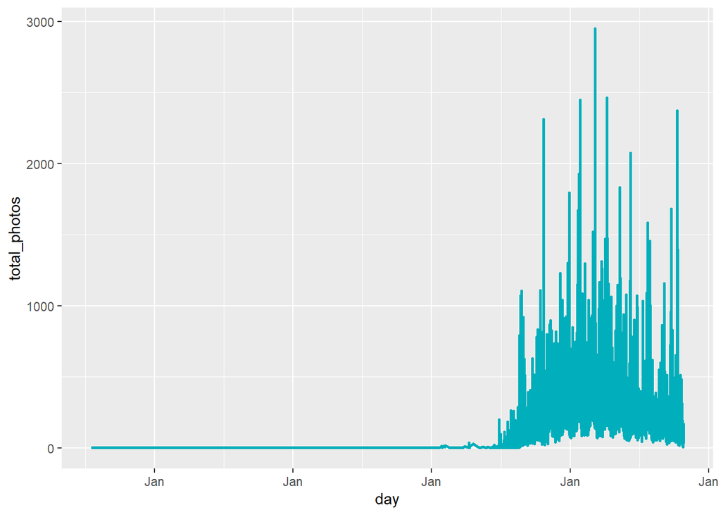

```r
p <- ggplot(daily_photography, aes(x = day, y = total_photos)) +
  geom_line(color = "#00AFBB", size = 1) +
  scale_x_date(date_labels = "%b")
p
```

5. We can apply a minimum to make the plot more legible

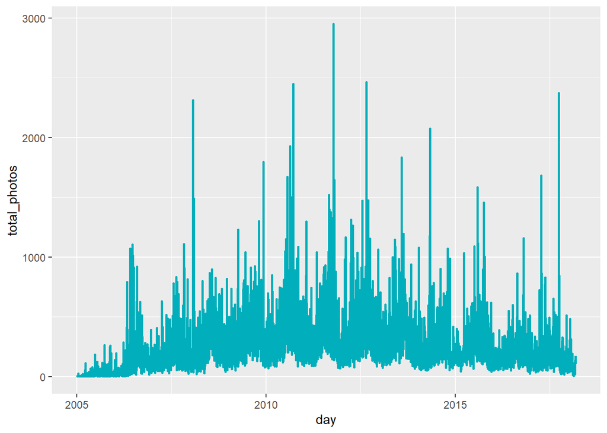

```r
## Let's set a minimum to omit the few points
## in before 2005
min <- as.Date("2005-1-1")
max <- NA

# Set axis limits c(min, max)
p + scale_x_date(limits = c(min, max))
```

6. Let’s smooth this data to see the trend of photographic sharing for the State.

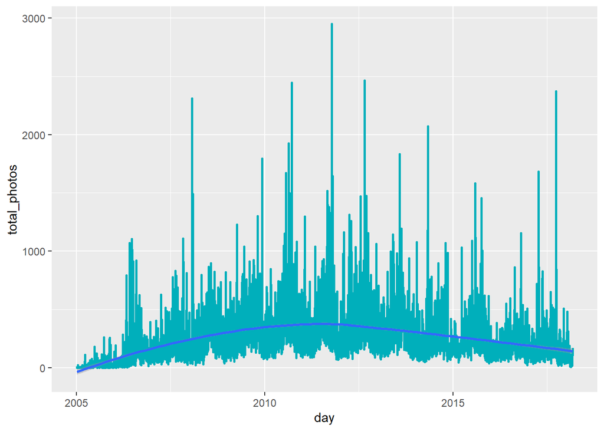

```r
p + stat_smooth(method = "loess", formula = y ~ x, size = 1) +
scale_x_date(limits = c(min, max))
```

We can also smooth it based on a spline function.

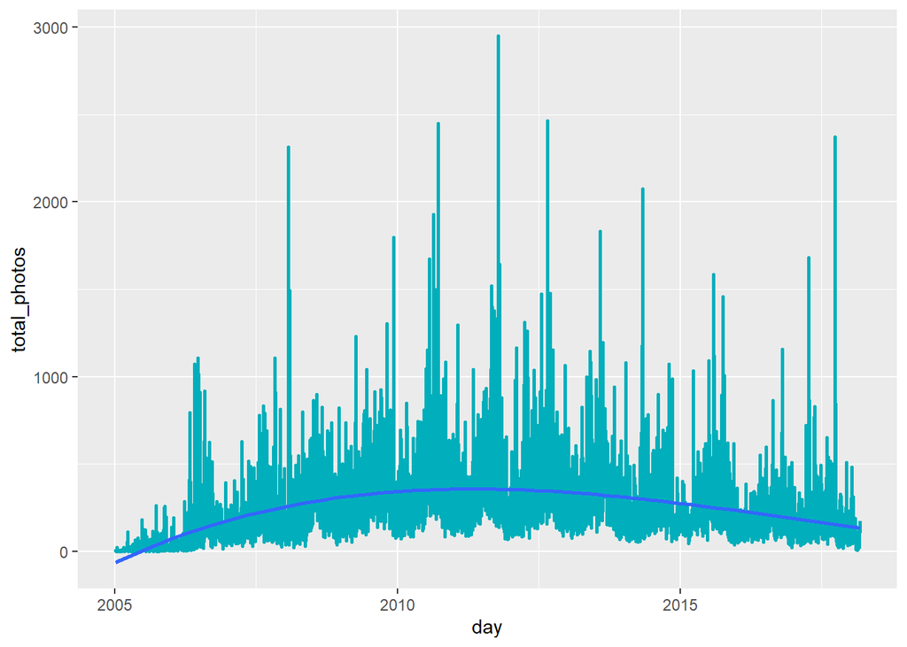

```r
p + geom_smooth(method = lm, formula = y ~ splines::bs(x, 3), se = FALSE) +
scale_x_date(limits = c(min, max))
```

7. We can also graph different categories of data at the same time. Here we can distinguish between nature and non-nature photographs.

```r
daily_nature <- MichFlickr %>%
  mutate(day = as.Date(date, format="%Y-%m-%d")) %>%
  group_by(day, Nature) %>% # group by the day column
  summarise(total_photos=sum(count))
```

[output not shown]

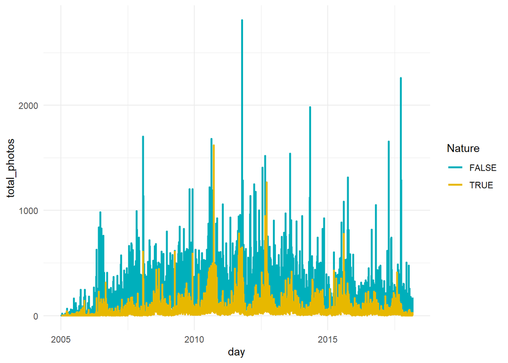

```r
ggplot(daily_nature, aes(x = day, y = total_photos)) +
  geom_line(aes(color = Nature), size = 1) +
  scale_color_manual(values = c("#00AFBB", "#E7B800")) +
  scale_x_date(limits = c(min, max)) +
  theme_minimal()
```

7.Let’s check if there is a monthly pattern of sharing photograph through Flickr. First we will use the `mutate()` function to parse the month and year from the date data. Here we are using the lubridate function to grab this data. [Here](https://rawgit.com/rstudio/cheatsheets/master/lubridate.pdf) is a cheatsheet for the lubridate package. We will summerize the total number of photographs based on the year and month using group_by (sometimes there are issues with this function due to different package dependancies dplyer and ggplot).

```r
daily_monthly <- daily_photography %>%
    mutate(month =  month(ymd(daily_photography$day), label = TRUE, abbr = FALSE),
           year  = year(as.Date(day, format = "%Y-%m-%d"))) %>%
    group_by(year,month) %>%
    summarise(total.qty = sum(total_photos))
daily_monthly
```

```
## # A tibble: 190 × 3
## # Groups:   year [21]
##     year month     total.qty
##    <dbl> <ord>         <dbl>
##  1  1975 June              1
##  2  1979 April             1
##  3  1979 August            1
##  4  2000 April             1
##  5  2000 June              2
##  6  2000 September        32
##  7  2000 November         14
##  8  2000 December         23
##  9  2001 April             7
## 10  2001 May               4
## # ℹ 180 more rows
```

8. Now that we have summarized this data in to another dataframe we can plot the different years of photography by month.

[figure not shown]

```r
daily_monthly  %>%
    filter(year > 2004)  %>%
    ggplot(aes(x = month, y = total.qty, group = year)) +
    geom_line(aes(color = as.factor(year))) +
    scale_color_discrete() +
    labs(title = "Total Flickr Photographs for Michigan", x = "", y = "Total Photographs",
         subtitle = "Activity is highest for the summer months") +
   theme_classic()
```

9. We can also do a similar weekly analysis. First we make dataframe that summerizes the data per week

```r
weekly <- daily_photography %>%
    mutate(weekday =  wday(ymd(daily_photography$day), label = TRUE, abbr = FALSE),
           year  = year(as.Date(day, format = "%Y-%m-%d"))) %>%
    group_by(year,weekday) %>%
    summarise(total.qty = sum(total_photos))
weekly
```

```
## # A tibble: 129 × 3
## # Groups:   year [21]
##     year weekday   total.qty
##    <dbl> <ord>         <dbl>
##  1  1975 Sunday            1
##  2  1979 Monday            1
##  3  1979 Saturday          1
##  4  2000 Sunday            1
##  5  2000 Monday           20
##  6  2000 Tuesday          19
##  7  2000 Wednesday         1
##  8  2000 Thursday         19
##  9  2000 Friday           12
## 10  2001 Monday            3
## # ℹ 119 more rows
```

Now we can plot this data.

[figure not shown]

```r
weekly  %>%
    filter(year > 2004)  %>%
    ggplot(aes(x = weekday, y = total.qty, group = year)) +
    geom_line(aes(color = as.factor(year))) +
    scale_color_discrete() +
    labs(title = "Total Flickr Photographs for Michigan", x = "", y = "Total Photographs",
         subtitle = "Activity is highest on the weekends") +
  theme_bw()
```

10. We can also look at peaks in time series data using the ggpmisc package, which was extension to ggplot. The extension emphasizes annotations and highlighting related to fitted models and data summaries. This is shown as text, tables and implemented using different equations. ggplot methods. For example, label the peaks of time series using stat_peaks. First let organize the data to include the date, month and year for filter to specific time periods. Let’s also grab only nature photographs.

```r
library(ggpmisc)
daily_nature_only <- MichFlickr %>%
 mutate(year = year(as.Date(date, format = "%Y-%m-%d")),
        month =  month(ymd(date), label = TRUE, abbr = FALSE)) %>%
  filter(Nature == TRUE) %>%
  group_by(date, year, month) %>% # group by the day column
  summarise(total_photos=sum(count))
daily_nature_only
```

```
## # A tibble: 4,650 × 4
## # Groups:   date, year [4,650]
##    date        year month     total_photos
##    <date>     <dbl> <ord>            <dbl>
##  1 2000-04-23  2000 April                1
##  2 2001-04-18  2001 April                1
##  3 2002-04-10  2002 April                1
##  4 2002-05-16  2002 May                  1
##  5 2002-09-17  2002 September            3
##  6 2003-09-20  2003 September            1
##  7 2004-03-23  2004 March                1
##  8 2004-03-24  2004 March                1
##  9 2004-06-30  2004 June                 8
## 10 2004-07-22  2004 July                 9
## # ℹ 4,640 more rows
```

11. Now we will plot the peaks and valleys by adding the stat_peaks and stat_valleys argument to the typical ggplot format. The arguments indicate what color to give and the time series peaks and valleys. We also have to use the POSIXct.

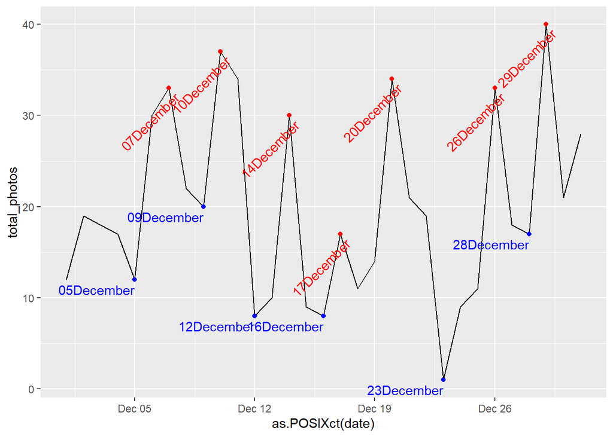

```r
daily_nature_only  %>%
    filter(year == '2011' & month=='December')  %>%
ggplot(aes(x = as.POSIXct(date), y = total_photos), as.numeric = FALSE) +
  geom_line() +
  stat_peaks(colour = "red") +
  stat_peaks(geom = "text", colour = "red", angle = 45,
               vjust = 1.5, hjust = 1,  x.label.fmt = "%d%B") +
  stat_valleys(colour = "blue") +
 stat_valleys(geom = "text", colour = "blue", angle = 360,
             vjust = 1.5, hjust = 1,  x.label.fmt = "%d%B")
```

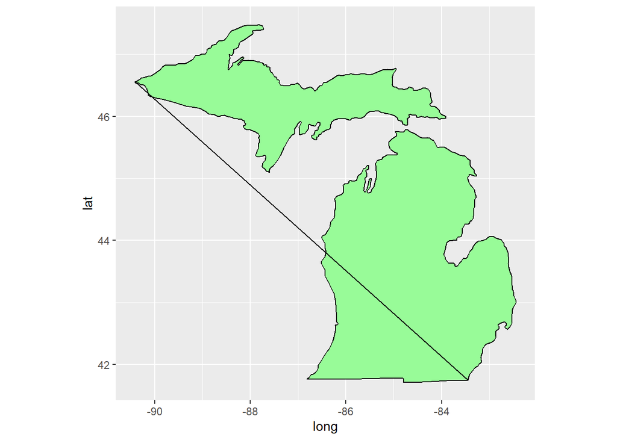

```r
######Data for Michigan
states <- map_data("state")
mich <- subset(states, region == "michigan")
mich <- states %>%
  filter(region == "michigan")
counties <- map_data("county")
mich_county <- subset(counties, region == "michigan")


ggplot(data = mich) +
  geom_polygon(aes(x = long, y = lat), fill = "palegreen", color = "black") +
  coord_fixed(1.3)
```

```r
mich <- ggplot(data = mich, mapping = aes(x = long, y = lat, group = group)) +
  coord_fixed(1.3) +
  geom_polygon(color = "black", fill = "orange")
```

```r
MichFlickr$date <- as.Date(as.POSIXct(MichFlickr$dateupload, origin="1970-01-01"))
#min <- as.Date("2008-01-01")
#max  <- as.Date("2015-01-01")
animateMich <- MichFlickr %>%
  filter( date >= as.Date('2010-01-01') & date <= as.Date('2010-12-31'))
```

## Assignment

1. Conduct a comprehensive exploration of the spatiotemporal nuances within the provided social media dataset. This could, for example, investigate the underlying factors contributing to the observed differences between nature and non-nature photographs, or analyze the temporal and geographic variations that might account for specific trends in photograph sharing. You are expected to employ advanced statistical and geospatial techniques to delve deeper into this phenomenon. To substantiate your findings, create compelling visual representations that effectively illustrate the spatiotemporal dynamics at play. Provide a robust argument based on your analytical insights.

Let’s assume that locations of Nature and Not-Nature Photos will be spatially and temporaly different, that we can calculate the mean point(mean lons & mean lats) of each date’s photo taking locations, and use line to connect the points in a sequence and use different colors to display them by month. Here are the animation of the route of Nature type photos’ mean points:

```r
library(transformr)
```

```
## `geom_path()`: Each group consists of only one observation.
## ℹ Do you need to adjust the group aesthetic?
## `geom_path()`: Each group consists of only one observation.
## ℹ Do you need to adjust the group aesthetic?
```

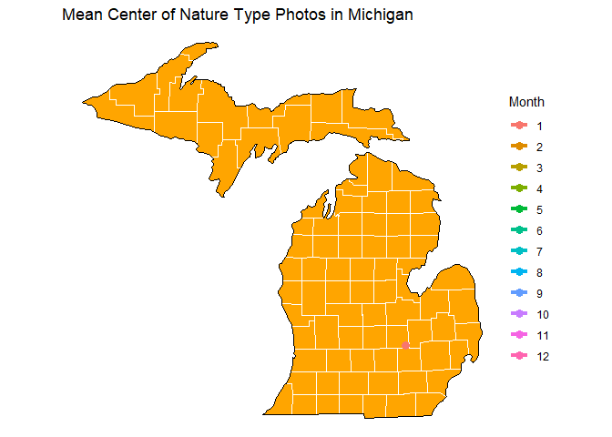

```r
library(tidyr)
animateMichNature <-animateMich %>%
filter(date >= as.Date('2010-01-01') & date <= as.Date('2010-12-31') & Nature == "TRUE")

# Calculate mean points on each day and add month column
mean_point_Nature <- animateMichNature %>%
  group_by(date) %>%
  summarise(mean_lon = mean(longitude, na.rm = TRUE),
            mean_lat = mean(latitude, na.rm = TRUE)) %>%
  mutate(month = lubridate::month(date))

p3 <- mich + theme_void() +
  geom_polygon(data = mich_county, fill = NA, color = "white") +
  geom_polygon(color = "black", fill = NA) +
  # Plot the historical mean points with geom_path before the transition
  geom_path(data = mean_point_Nature, aes(mean_lon, mean_lat, group = 1, color = as.factor(month)), size = 1.5) +
  geom_point(data = mean_point_Nature, aes(mean_lon, mean_lat, group = 1, color = as.factor(month)), size = 3) +
  ggtitle('Mean Center of Nature Type Photos in Michigan')+
  transition_reveal(date) +
  # Optional: Add a legend title for the colour aesthetic
  scale_color_discrete(name = "Month")

animate(p3, fps = 2)
```

From the animation we can see that the location of mean point varies a lot by month. Now we do the same thing of Not-Nature type photos.

```
## `geom_path()`: Each group consists of only one observation.
## ℹ Do you need to adjust the group aesthetic?
## `geom_path()`: Each group consists of only one observation.
## ℹ Do you need to adjust the group aesthetic?
```

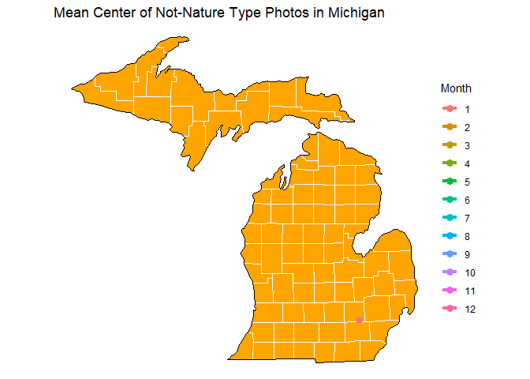

```r
animateMichNotNature <-animateMich %>%
filter(date >= as.Date('2010-01-01') & date <= as.Date('2010-12-31') & Nature == "FALSE")

# Calculate mean points on each day and add month column
mean_point_notNature <- animateMichNotNature %>%
  group_by(date) %>%
  summarise(mean_lon = mean(longitude, na.rm = TRUE),
            mean_lat = mean(latitude, na.rm = TRUE)) %>%
  mutate(month = lubridate::month(date))

p3 <- mich + theme_void() +
  geom_polygon(data = mich_county, fill = NA, color = "white") +
  geom_polygon(color = "black", fill = NA) +
  # Plot the historical mean points with geom_path before the transition
  geom_path(data = mean_point_notNature, aes(mean_lon, mean_lat, group = 1, color = as.factor(month)), size = 1.5) +
  geom_point(data = mean_point_notNature, aes(mean_lon, mean_lat, group = 1, color = as.factor(month)), size = 3) +
  ggtitle('Mean Center of Not-Nature Type Photos in Michigan')+
  transition_reveal(date) +
  # Optional: Add a legend title for the colour aesthetic
  scale_color_discrete(name = "Month")

animate(p3, fps = 2)
```

From the result we can see that the mean points seems distribute more tightly in lower bottom part in Lower Peninsula, majorly around large cities like Grand Rapids, Lansing and Detroit. What’s more, we can plot the variance of longitudes and latitudes of Nature and Not-Nature type photos to see the difference of their changing trends during a year.

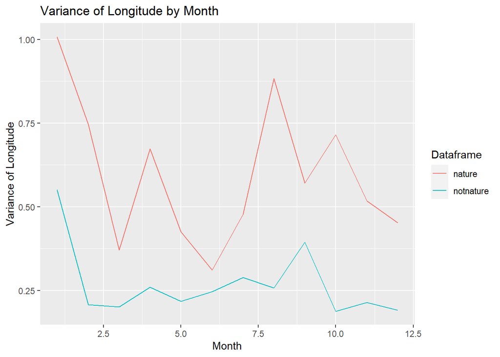

```r
variance_nature <- mean_point_Nature %>%
  mutate(month = lubridate::month(date)) %>%
  group_by(month) %>%
  summarise(var_lon = var(mean_lon, na.rm = TRUE),
            var_lat = var(mean_lat, na.rm = TRUE))

variance_notNature <- mean_point_notNature %>%
  mutate(month = lubridate::month(date)) %>%
  group_by(month) %>%
  summarise(var_lon = var(mean_lon, na.rm = TRUE),
            var_lat = var(mean_lat, na.rm = TRUE))

variance_nature$type <- "nature"
variance_notNature$type <- "notnature"
combined_variance <- bind_rows(variance_nature, variance_notNature)

# Now, plot the combined data frame
# Plot variance of longitude
ggplot(combined_variance, aes(x = month, y = var_lon, color = type)) +
  geom_line() +
  labs(x = "Month", y = "Variance of Longitude",
       title = "Variance of Longitude by Month",
       color = "Dataframe")
```

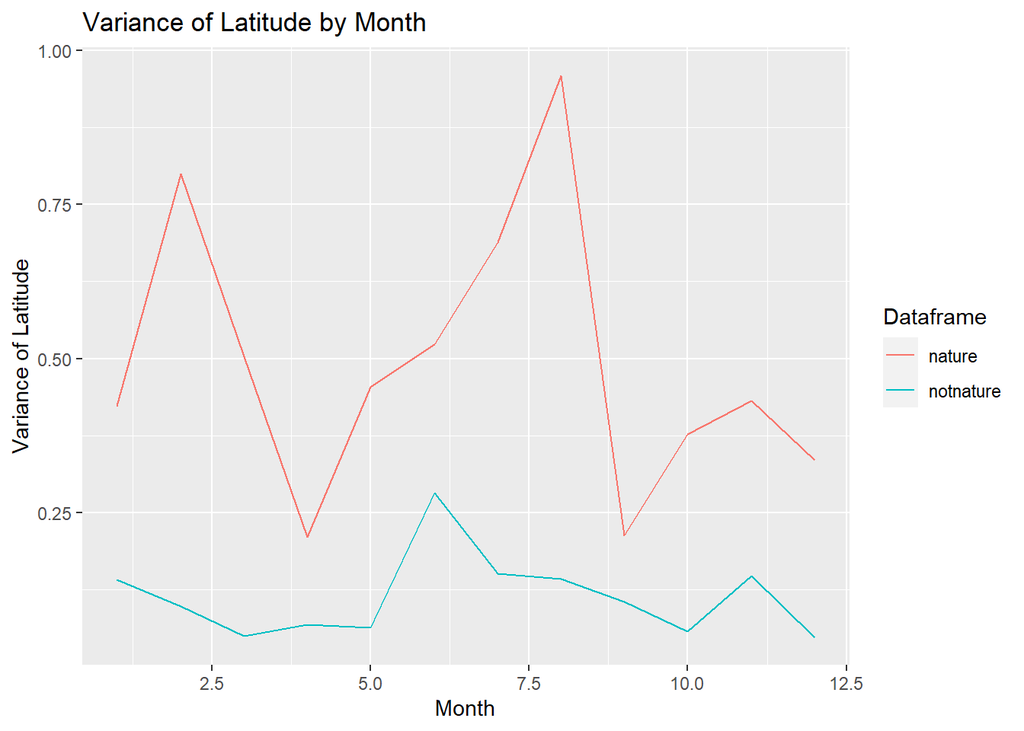

```r
# Plot variance of latitude
ggplot(combined_variance, aes(x = month, y = var_lat, color = type)) +
  geom_line() +
  labs(x = "Month", y = "Variance of Latitude",
       title = "Variance of Latitude by Month",
       color = "Dataframe")
```

From the graphs we can summarize these characteristics of the variance of lons and lats: (1) Nature and Not-Nature photos’ variance of Longitude&Latitude will show different changing trend from June to November, which happen seems to be the non-snowing seasons of Michigan, that indicates that people/tourists will separately doing nature activities(taking Nature photos) and non-nature activities(taking Not-Nature photos) in different places during these months. (2) Both Nature photos’ variance of Longitude&Latitude are greater than Non-Nature variance, that indicates that places that people willing to taking Nature photos are more disperse than places taking Non-Nature photos.

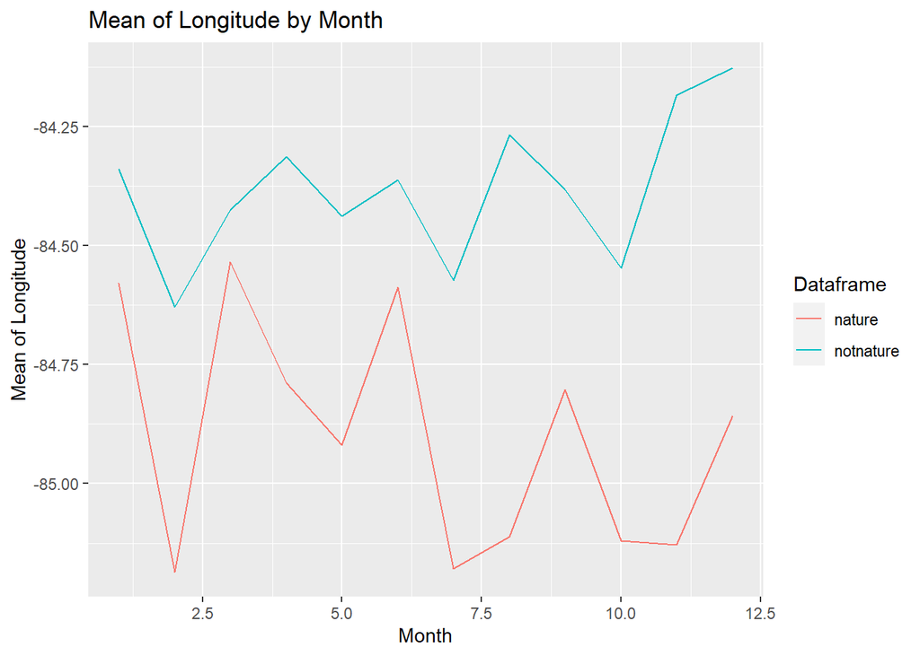

```r
mean_nature <- mean_point_Nature %>%
  mutate(month = lubridate::month(date)) %>%
  group_by(month) %>%
  summarise(mean_lon = mean(mean_lon, na.rm = TRUE),
            mean_lat = mean(mean_lat, na.rm = TRUE))

mean_notNature <- mean_point_notNature %>%
  mutate(month = lubridate::month(date)) %>%
  group_by(month) %>%
  summarise(mean_lon = mean(mean_lon, na.rm = TRUE),
            mean_lat = mean(mean_lat, na.rm = TRUE))

mean_nature$type <- "nature"
mean_notNature$type <- "notnature"
combined_mean <- bind_rows(mean_nature, mean_notNature)

# Now, plot the combined data frame
# Plot mean of longitude
ggplot(combined_mean, aes(x = month, y = mean_lon, color = type)) +
  geom_line() +
  labs(x = "Month", y = "Mean of Longitude",
       title = "Mean of Longitude by Month ",
       color = "Dataframe")
```

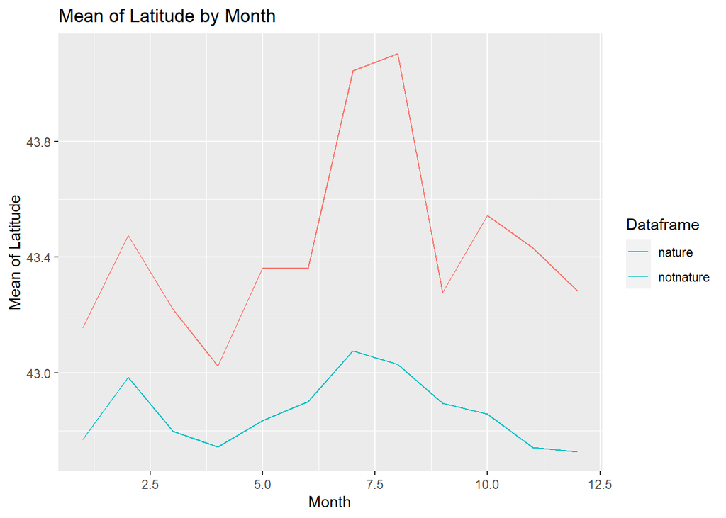

```r
# Plot variance of latitude
ggplot(combined_mean, aes(x = month, y = mean_lat, color = type)) +
  geom_line() +
  labs(x = "Month", y = "Mean of Latitude",
       title = "Mean of Latitude by Month",
       color = "Dataframe")
```

2. Social media data include various sources of noise related to the frequency of sharing photographs that can obscure meaningful patterns. Your task is to develop a technique for noise reduction that surpasses basic filtering methods. Additionally, generate a visually engaging GIF that elucidates the spatiotemporal dynamics within the data. Alongside this, propose a hypothesis that elucidates the observed patterns based on your knowledge of the region and geographic processes. Your hypothesis should reflect your understanding of the factors of social media sharing and how they influence the temporal and spatial aspects of photograph sharing.

In this Flickr dataset I notice that one user may upload multiple photos in the same data at the same spot, which might cause noise to the following analysis that these duplicate photos will just provide one single point of information to the analysis. So my filtering method for the noise is that using `distinct` function in dplyr library to filter the duplicate photos. We assume that due to spots for photo-taking tend to more disperse and isolated in nature type areas, and people will be more excited in taking photos as souvenirs and memories people may take, the variance of filtered dataset and non-filtered dataset will be larger in traveling season than other seasons since people may add more “noise” photos to the dataset in traveling season.

1.Data Filtering According to the methodology I mentioned above, we first filter out the ‘noise’ from the original dataset.

```r
library(dplyr)

animateMich$Round_lat <- round(animateMich$latitude,3)
animateMich$Round_lon <- round(animateMich$longitude,3)
animateMich_filtered <- animateMich %>%
  distinct(owner, date, Round_lat, Round_lon, .keep_all = TRUE)
```

2.Nature Photos’ Location Visualization

```
## `geom_path()`: Each group consists of only one observation.
## ℹ Do you need to adjust the group aesthetic?
## `geom_path()`: Each group consists of only one observation.
## ℹ Do you need to adjust the group aesthetic?
```

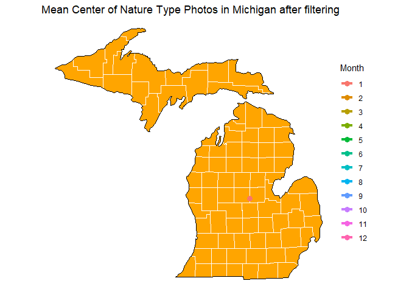

```r
animateMichNature_filter <-animateMich_filtered %>%
filter(date >= as.Date('2010-01-01') & date <= as.Date('2010-12-31') & Nature == "TRUE")

# Calculate mean points on each day and add month column
mean_point_Nature_filter <- animateMichNature_filter %>%
  group_by(date) %>%
  summarise(mean_lon = mean(longitude, na.rm = TRUE),
            mean_lat = mean(latitude, na.rm = TRUE)) %>%
  mutate(month = lubridate::month(date))

p <- mich + theme_void() +
  geom_polygon(data = mich_county, fill = NA, color = "white") +
  geom_polygon(color = "black", fill = NA) +
  # Plot the historical mean points with geom_path before the transition
  geom_path(data = mean_point_Nature_filter, aes(mean_lon, mean_lat, group = 1, color = as.factor(month)), size = 1.5) +
  geom_point(data = mean_point_Nature_filter, aes(mean_lon, mean_lat, group = 1, color = as.factor(month)), size = 3) +
  ggtitle('Mean Center of Nature Type Photos in Michigan after filtering')+
  transition_reveal(date) +
  # Optional: Add a legend title for the colour aesthetic
  scale_color_discrete(name = "Month")

animate(p, fps = 2)
```

3.Non Nature Photos’ Location Visualization

```
## `geom_path()`: Each group consists of only one observation.
## ℹ Do you need to adjust the group aesthetic?
## `geom_path()`: Each group consists of only one observation.
## ℹ Do you need to adjust the group aesthetic?
```

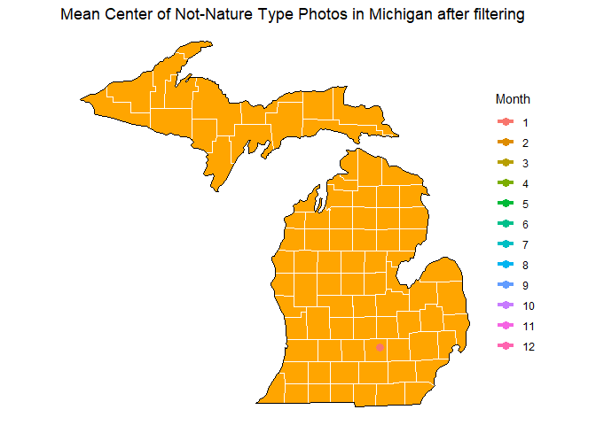

```r
animateMichNotNature_filter <-animateMich_filtered %>%
filter(date >= as.Date('2010-01-01') & date <= as.Date('2010-12-31') & Nature == "FALSE")

# Calculate mean points on each day and add month column
mean_point_notNature_filter <- animateMichNotNature_filter %>%
  group_by(date) %>%
  summarise(mean_lon = mean(longitude, na.rm = TRUE),
            mean_lat = mean(latitude, na.rm = TRUE)) %>%
  mutate(month = lubridate::month(date))

p <- mich + theme_void() +
  geom_polygon(data = mich_county, fill = NA, color = "white") +
  geom_polygon(color = "black", fill = NA) +
  # Plot the historical mean points with geom_path before the transition
  geom_path(data = mean_point_notNature_filter, aes(mean_lon, mean_lat, group = 1, color = as.factor(month)), size = 1.5) +
  geom_point(data = mean_point_notNature_filter, aes(mean_lon, mean_lat, group = 1, color = as.factor(month)), size = 3) +
  ggtitle('Mean Center of Not-Nature Type Photos in Michigan after filtering')+
  transition_reveal(date) +
  # Optional: Add a legend title for the colour aesthetic
  scale_color_discrete(name = "Month")

animate(p, fps = 2)
```

4.Variance Visualization Lastly we plot the variance of the mean points of the filtered dataset and original dataset and see whether there is any difference.

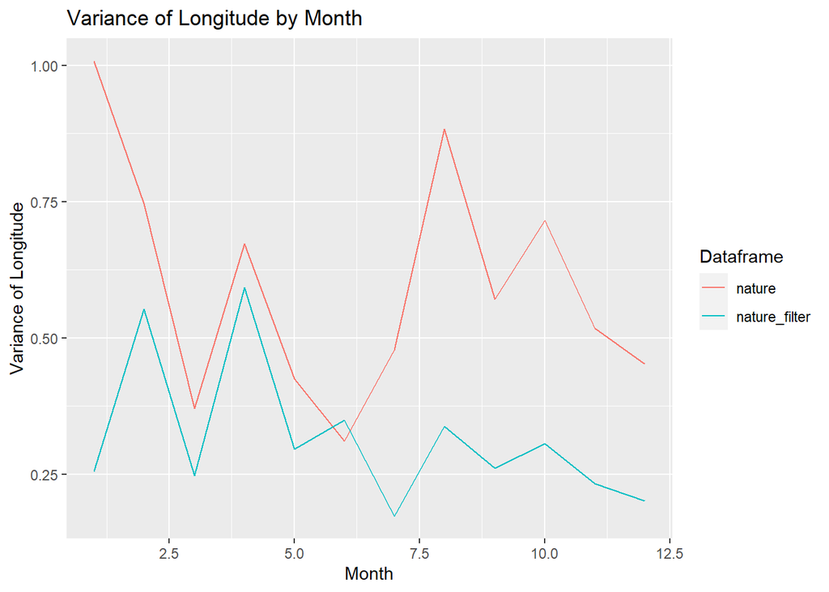

```r
variance_nature_filter <- mean_point_Nature_filter %>%
  mutate(month = lubridate::month(date)) %>%
  group_by(month) %>%
  summarise(var_lon = var(mean_lon, na.rm = TRUE),
            var_lat = var(mean_lat, na.rm = TRUE))

variance_notNature_filter <- mean_point_notNature_filter %>%
  mutate(month = lubridate::month(date)) %>%
  group_by(month) %>%
  summarise(var_lon = var(mean_lon, na.rm = TRUE),
            var_lat = var(mean_lat, na.rm = TRUE))

variance_nature_filter$type <- "nature_filter"
variance_notNature_filter$type <- "notnature_filter"
combined_nature_filter <- bind_rows(variance_nature, variance_nature_filter)
combined_notNature_filter <- bind_rows(variance_notNature,variance_notNature_filter)

# Now, plot the combined data frame
# Plot mean of longitude
ggplot(combined_nature_filter, aes(x = month, y = var_lon, color = type)) +
  geom_line() +
  labs(x = "Month", y = "Variance of Longitude",
       title = "Variance of Longitude by Month",
       color = "Dataframe")
```

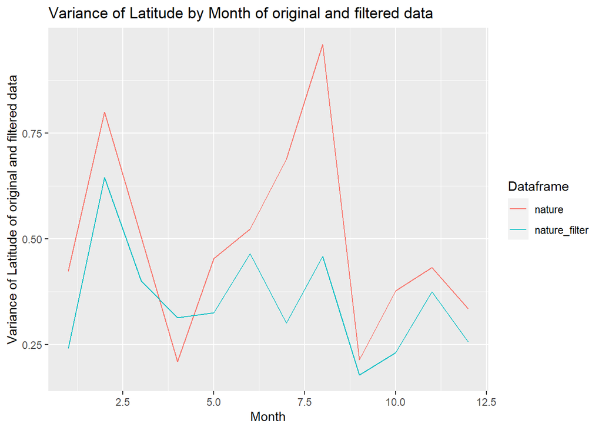

```r
# Plot variance of latitude
ggplot(combined_nature_filter, aes(x = month, y = var_lat, color = type)) +
  geom_line() +
  labs(x = "Month", y = "Variance of Latitude of original and filtered data",
       title = "Variance of Latitude by Month of original and filtered data",
       color = "Dataframe")
```

We can find that in terms of longitude, two datasets have difference in months from July to December, which may indicate that traveling seasons in Michigan are from July to December and January. The figure of latitude also indicates that January, May, July, August and October, which also make sense in some degree according to Michigan’s ideal tourist seasons given by Google.